# Initial Result and Code

Note: So far this is what I have for my project, and things will be subject to change as I progress through the capstone and towards the final results and report.

Load the Dataset

```r
data <- read.csv('C:/Users/Ryan/Desktop/Capstone/listings.csv')
str(data)
```

```
## 'data.frame':    37728 obs. of  106 variables:
##  $ id                                          : int  109 344 2708 2732 2864 3021 5728 5729 5843 6033 ...
##  $ listing_url                                 : Factor w/ 37728 levels "https://www.airbnb.com/rooms/10000255",..: 481 21558 14528 14722 15900 17441 34749 34752 34828 34939 ...
##  $ scrape_id                                   : num  2.02e+13 2.02e+13 2.02e+13 2.02e+13 2.02e+13 ...
##  $ last_scraped                                : Factor w/ 4 levels "2020-04-14","2020-04-15",..: 2 2 1 1 1 2 1 1 1 2 ...
##  $ name                                        : Factor w/ 37000 levels "","'20s Showplace With Mid-Century Decor in Hancock Park",..: 3922 14623 22062 36970 582 17228 34285 36983 4521 25634 ...
##  $ summary                                     : Factor w/ 32576 levels "","'Casita Esme' is truly charming.  The enclosed private yard is landscaped with an ever-green lawn (synthetic gr"| __truncated__,..: 363 26822 19244 1 6815 2816 19518 19519 9291 19371 ...
##  $ space                                       : Factor w/ 25077 levels "","'Cloud 9' is stylishly appointed with a modern surf side chic decor and all the modern entertainment and living"| __truncated__,..: 346 4269 6317 19840 17777 14927 5282 5283 12277 23901 ...
##  $ description                                 : Factor w/ 34500 levels "","'Casita Esme' is truly charming.  The enclosed private yard is landscaped with an ever-green lawn (synthetic gr"| __truncated__,..: 388 28403 20383 28632 7179 2930 20672 20673 9767 20512 ...
##  $ experiences_offered                         : Factor w/ 1 level "none": 1 1 1 1 1 1 1 1 1 1 ...
##  $ neighborhood_overview                       : Factor w/ 20880 levels "","--  2 miles to Santa Monica beach  --  2 miles to Venice Beach -- near Getty Center + Hammer Museum -- walkable"| __truncated__,..: 1 10851 19684 16928 20367 16940 10155 10155 10156 1 ...
##  $ notes                                       : Factor w/ 15294 levels "","---------------------------------------------------------------------------------------------------------- CORO"| __truncated__,..: 1 7137 2217 1 5076 1 8081 8081 8081 140 ...
##  $ transit                                     : Factor w/ 19034 levels "","-- easy street parking [be careful during street cleaning!] -- close to major bus routes on Santa Monica Blvd -"| __truncated__,..: 1 10582 12807 16324 9901 3080 18502 18503 18502 5724 ...
##  $ access                                      : Factor w/ 18252 levels "","--- More Amenities - 60\" TV with premium cable & Amazon fire stick  - High speed internet - A/C  - 2 car priva"| __truncated__,..: 1 10577 8682 1 4582 1 16139 16156 17986 3990 ...
##  $ interaction                                 : Factor w/ 19206 levels "","- A comprehensive House guide to show how to operate the home.   We are on call at all times to assist you with your stay!",..: 1 3731 6190 1 5149 1 3636 3637 3636 1 ...
```

[output cut: 86 more lines]

Removing Redundant and not relevant variables for analysis e.g.(Repeated variables that represent the same thing)

```r
data$listing_url<-NULL # Not useful for analysis knowing the URL
data$scrape_id<-NULL # Not useful for analysis knowing the scrape ID
data$experiences_offered<-NULL # There is only one value it is none, since theres are all living spaces no experiences offered
data$thumbnail_url<-NULL #URL Links not useful for analysis and most are NA values
data$medium_url<-NULL #URL Links not useful for analysis and most are NA values
data$picture_url<-NULL #URL Links not useful for analysis
data$xl_picture_url<-NULL #URL Links not useful for analysis and most are NA values
data$thumbnail_url<-NULL #URL Links not useful for analysis
data$medium_url<-NULL #URL Links not useful for analysis
data$picture_url<-NULL #URL Links not useful for analysis
data$xl_picture_url<-NULL #URL Links not useful for analysis
data$host_url<-NULL #URL Links not useful for analysis
data$host_thumbnail_url<-NULL #URL Links not useful for analysis
data$host_picture_url<-NULL #URL Links not useful for analysis
data$host_name<-NULL #Already have ID , not need two have both
data$country_code<-NULL # We already know it's in the US and in LA metro area
data$country<-NULL# We already know it's in the US
data$state<-NULL #We already know it's in CA since it's in LA metro area
data$host_neighbourhood<-NULL # The location of the host maybe not be useful
data$host_location<-NULL
data$host_has_profile_pic<-NULL
data$neighbourhood<-NULL #There is already a cleansed version of the neighbourhood, so this should be more accurate to go off of
data$is_location_exact<- NULL # I believe that using the general location of the long and lat shuold be sufficient for analysis


#These are redundant numbers that are already shown by minimum_nights and maximum_nights column
data$maximum_maximum_nights<-NULL
data$maximum_minimum_nights<-NULL
data$maximum_nights_avg_ntm<-NULL
data$minimum_maximum_nights<-NULL
data$minimum_minimum_nights<-NULL
data$minimum_nights_avg_ntm<-NULL




data$market<-NULL # Already shown by City/Neighbourhod,it's going to be in LA metropolitan area,thus redundant information
data$smart_location<-NULL # Already shown by City/Neighbourhood
data$host_listings_count<-NULL # Doubled, there is already a total listings count


data$jurisdiction_names<-NULL #We already know that it is within the LA metro area
data$number_of_reviews_ltm<-NULL # Not really useful to know the amount last month, more interested in total
data$calculated_host_listings_count<-NULL #Repeated total listing counts for each host

data$license<-NULL # License number/ID not important for the analysis
data$is_business_travel_ready<-NULL #When checking the structure of the dataset, only one factor and it's all false
```

Fixing the Data types of variables

```r
str(data)
```

```
## 'data.frame':    37728 obs. of  73 variables:
##  $ id                                          : int  109 344 2708 2732 2864 3021 5728 5729 5843 6033 ...
##  $ last_scraped                                : Factor w/ 4 levels "2020-04-14","2020-04-15",..: 2 2 1 1 1 2 1 1 1 2 ...
##  $ name                                        : Factor w/ 37000 levels "","'20s Showplace With Mid-Century Decor in Hancock Park",..: 3922 14623 22062 36970 582 17228 34285 36983 4521 25634 ...
##  $ summary                                     : Factor w/ 32576 levels "","'Casita Esme' is truly charming.  The enclosed private yard is landscaped with an ever-green lawn (synthetic gr"| __truncated__,..: 363 26822 19244 1 6815 2816 19518 19519 9291 19371 ...
##  $ space                                       : Factor w/ 25077 levels "","'Cloud 9' is stylishly appointed with a modern surf side chic decor and all the modern entertainment and living"| __truncated__,..: 346 4269 6317 19840 17777 14927 5282 5283 12277 23901 ...
##  $ description                                 : Factor w/ 34500 levels "","'Casita Esme' is truly charming.  The enclosed private yard is landscaped with an ever-green lawn (synthetic gr"| __truncated__,..: 388 28403 20383 28632 7179 2930 20672 20673 9767 20512 ...
##  $ neighborhood_overview                       : Factor w/ 20880 levels "","--  2 miles to Santa Monica beach  --  2 miles to Venice Beach -- near Getty Center + Hammer Museum -- walkable"| __truncated__,..: 1 10851 19684 16928 20367 16940 10155 10155 10156 1 ...
##  $ notes                                       : Factor w/ 15294 levels "","---------------------------------------------------------------------------------------------------------- CORO"| __truncated__,..: 1 7137 2217 1 5076 1 8081 8081 8081 140 ...
##  $ transit                                     : Factor w/ 19034 levels "","-- easy street parking [be careful during street cleaning!] -- close to major bus routes on Santa Monica Blvd -"| __truncated__,..: 1 10582 12807 16324 9901 3080 18502 18503 18502 5724 ...
##  $ access                                      : Factor w/ 18252 levels "","--- More Amenities - 60\" TV with premium cable & Amazon fire stick  - High speed internet - A/C  - 2 car priva"| __truncated__,..: 1 10577 8682 1 4582 1 16139 16156 17986 3990 ...
##  $ interaction                                 : Factor w/ 19206 levels "","- A comprehensive House guide to show how to operate the home.   We are on call at all times to assist you with your stay!",..: 1 3731 6190 1 5149 1 3636 3637 3636 1 ...
##  $ house_rules                                 : Factor w/ 21353 levels "","---Check-in/Check-out: Check-in is at 2 p.m. or anytime thereafter provided you let us know the time.  Ring the"| __truncated__,..: 7585 9301 9776 6394 1 11170 2421 2421 2421 5408 ...
##  $ host_id                                     : int  521 767 3008 3041 3207 3415 9171 9171 9171 11619 ...
##  $ host_since                                  : Factor w/ 3566 levels "","2008-06-27",..: 2 3 6 7 8 9 19 19 19 22 ...
```

[output cut: 59 more lines]

```r
#These should be a character data type
data$name<-as.character(data$name)
data$summary<-as.character(data$summary)
data$space<-as.character(data$space)
data$description<-as.character(data$description)
data$neighborhood_overview<-as.character(data$neighborhood_overview)
data$notes<-as.character(data$notes)
data$transit<-as.character(data$transit)
data$access<-as.character(data$access)
data$interaction<-as.character(data$interaction)
data$house_rules<-as.character(data$house_rules)
data$host_since<-as.Date(data$host_since)
data$host_about<-as.character(data$host_about)

#Was not numeric
data$host_response_rate<-gsub('[%]','',data$host_response_rate)
data$host_response_rate<-as.numeric(data$host_response_rate)
data$host_acceptance_rate<-gsub('[%]','',data$host_acceptance_rate)
data$host_acceptance_rate<-as.numeric(data$host_acceptance_rate)
#Prices was not numeric
data$price<-gsub('[$]','',data$price)
data$price<-as.numeric(data$price)
data$weekly_price<-gsub('[$]','',data$weekly_price)
data$weekly_price<-as.numeric(data$weekly_price)
data$monthly_price<-gsub('[$]','',data$monthly_price)
data$monthly_price<-as.numeric(data$monthly_price)
data$security_deposit<-gsub('[$]','',data$security_deposit)
data$security_deposit<-as.numeric(data$security_deposit)
data$cleaning_fee<-gsub('[$]','',data$cleaning_fee)
data$cleaning_fee<-as.numeric(data$cleaning_fee)
data$extra_people<-gsub('[$]','',data$extra_people)
data$extra_people<-as.numeric(data$extra_people)

#After looking closely at the weekly price and monthly price , the amount don't actually checkout if you multiply the per night
#By 7 and there are many missing NA values for them as well.

length(which(is.na(data$monthly_price)==TRUE))
```

```
## [1] 37512
```

```r
length(which(is.na(data$weekly_price)==TRUE))
```

```
## [1] 35238
```

```r
data$weekly_price<-NULL
data$monthly_price<-NULL
#Better to remove the weekly/monthly prices due to the number of missing values, moreover AirBnb prices per night anyways


#Changing dates to datatype
data$last_scraped<-as.Date(data$last_scraped)
data$calendar_last_scraped<-as.Date(data$calendar_last_scraped)
data$first_review<-as.Date(data$first_review)
data$last_review<-as.Date(data$last_review)


#Cleaning amenities

data$amenities<-as.character(data$amenities)
data$amenities<-strsplit(data$amenities,",")
data$amenities<-gsub("[{}]","",data$amenities)
data$amenities<-gsub('["\"]',"",data$amenities)
```

Visualiztions of variables (histogram and boxplots)

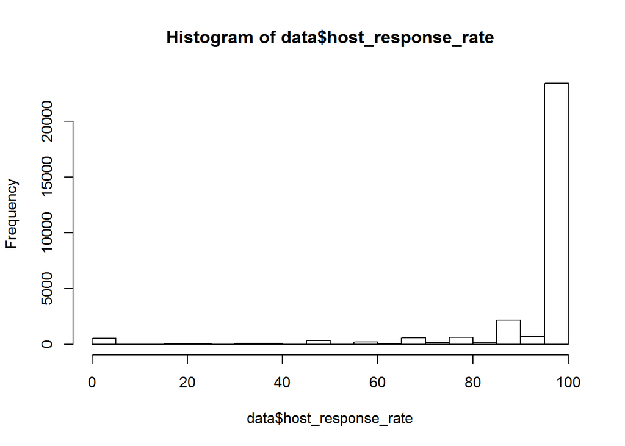

```r
#Histograms
hist(data$host_response_rate)
```

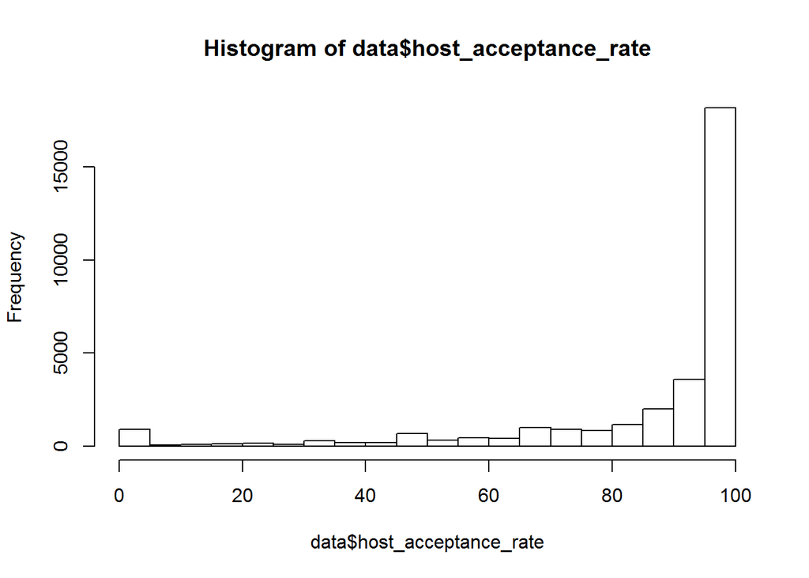

```r
hist(data$host_acceptance_rate)
```

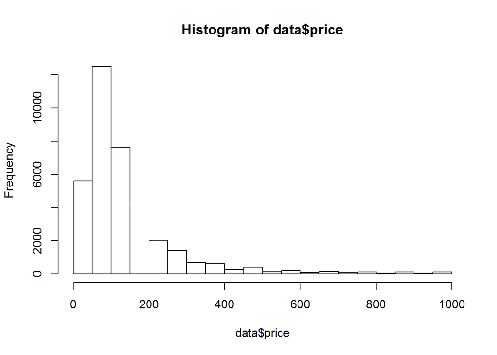

```r
hist(data$price)
```

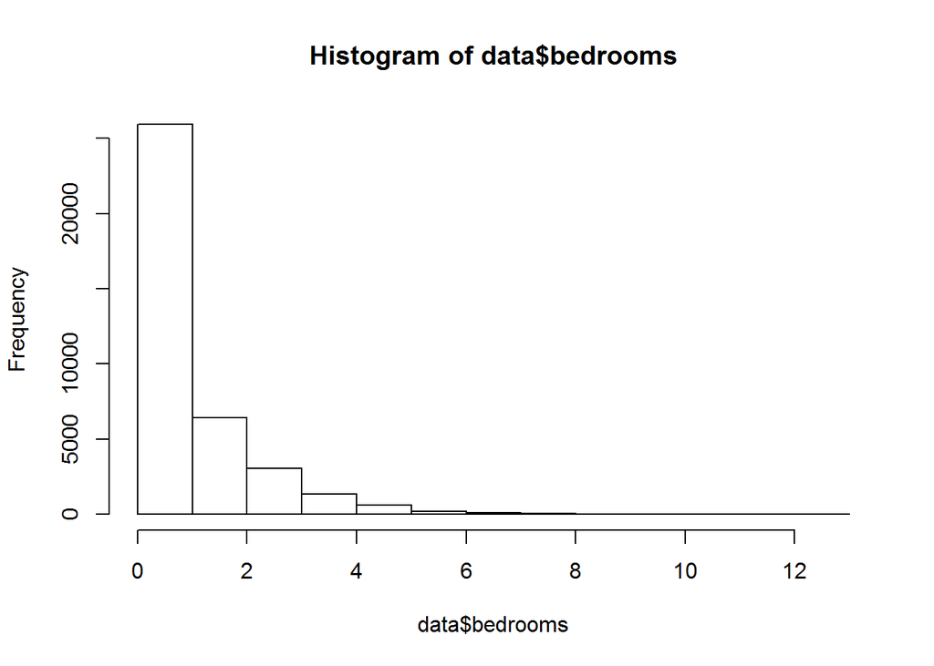

```r
hist(data$bedrooms)
```

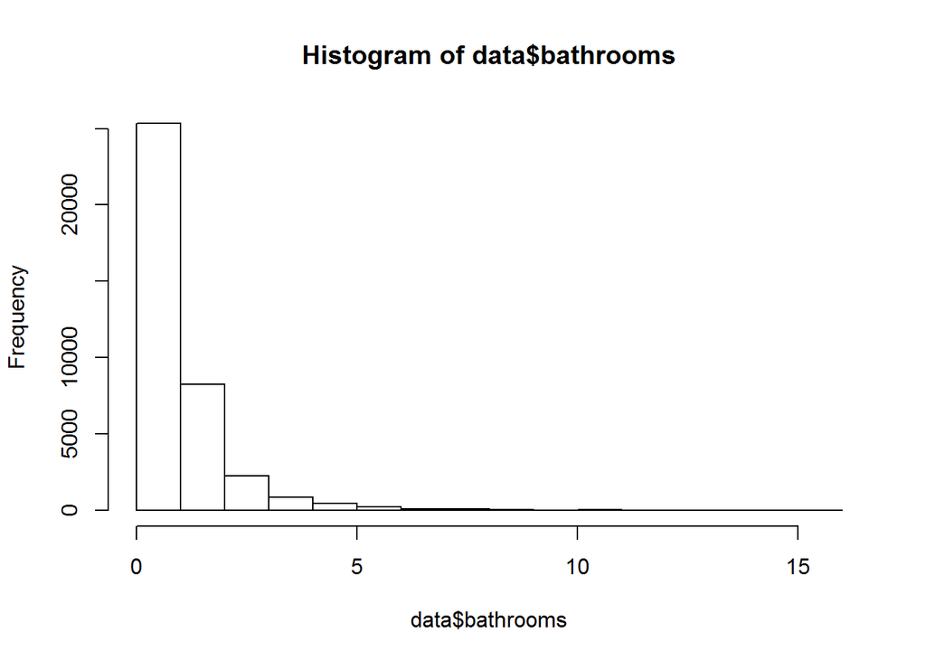

```r
hist(data$bathrooms)
```

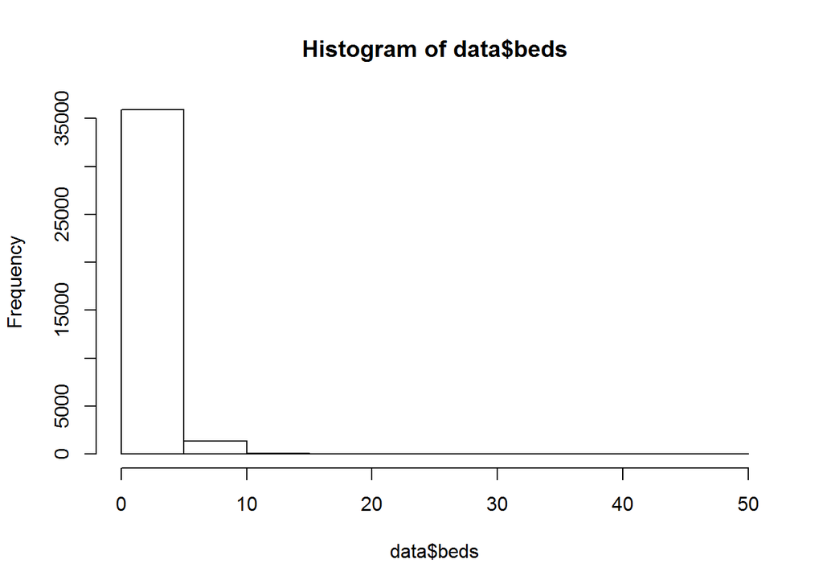

```r
hist(data$beds)
```

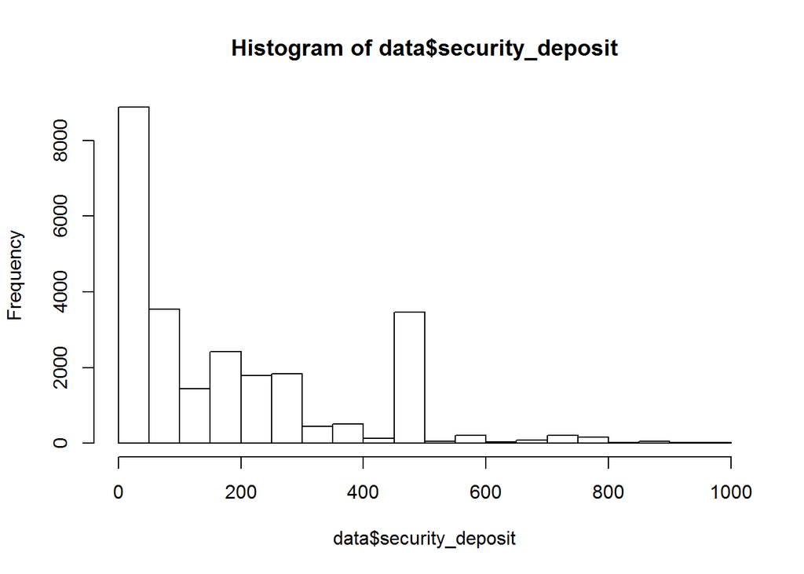

```r
hist(data$security_deposit)
```

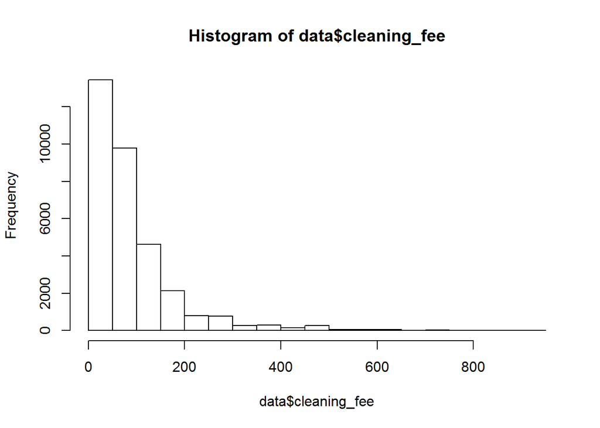

```r
hist(data$cleaning_fee)
```

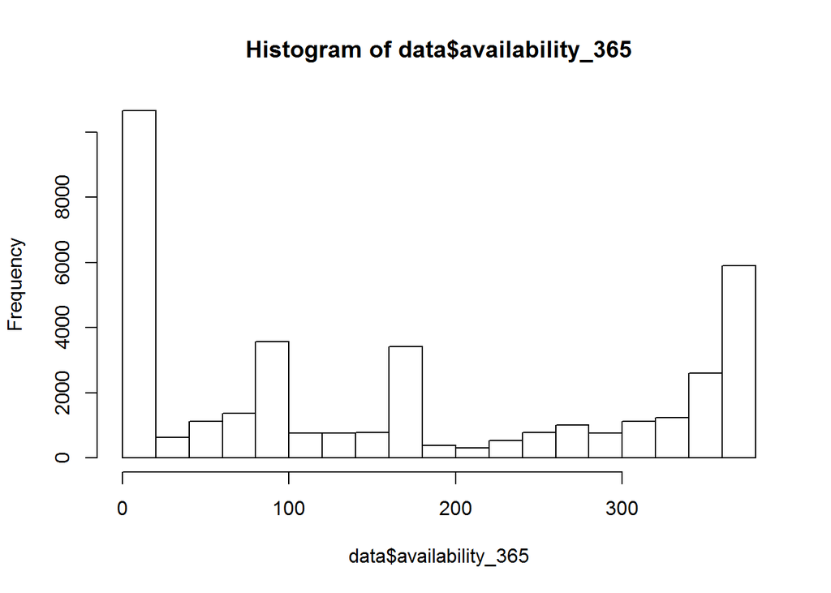

```r
hist(data$availability_365)
```

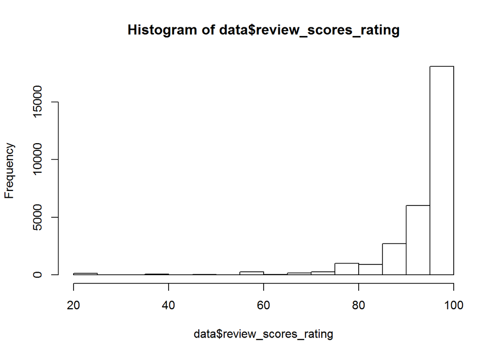

```r
hist(data$review_scores_rating)
```

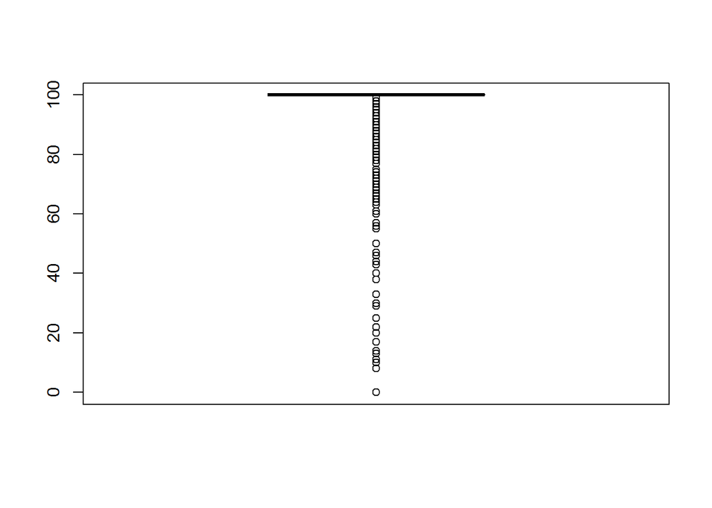

```r
#Boxplots
boxplot(data$host_response_rate)
```

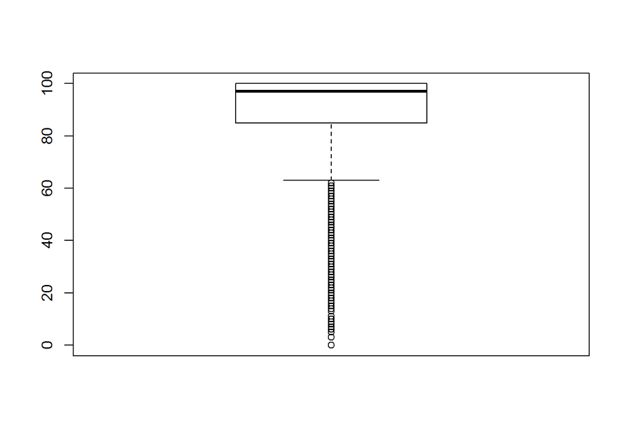

```r
boxplot(data$host_acceptance_rate)
```

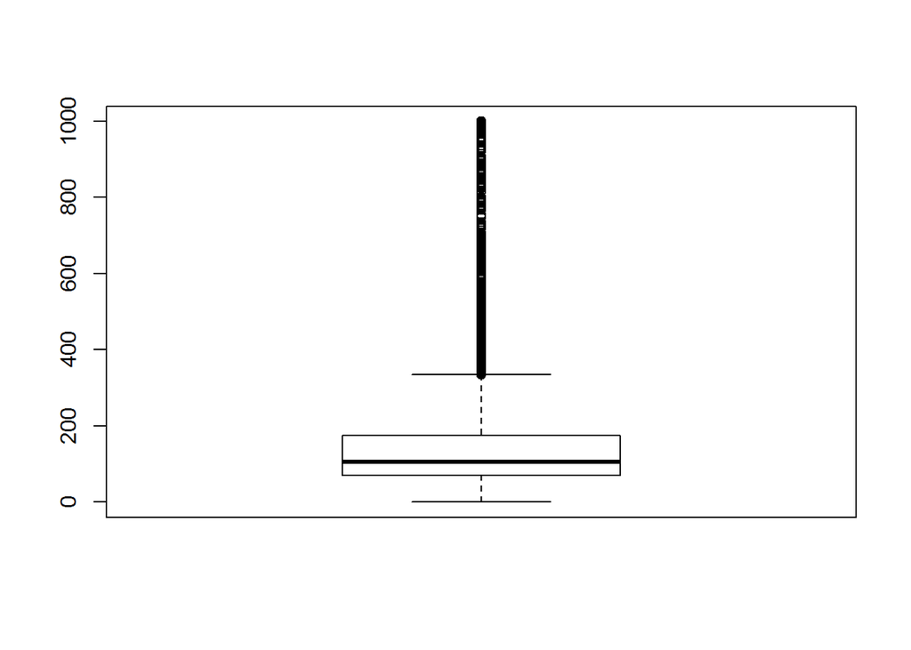

```r
boxplot(data$price)
```

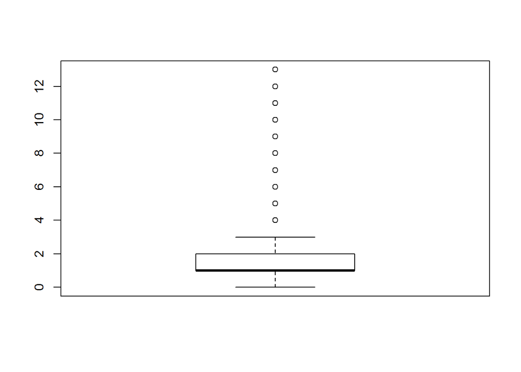

```r
boxplot(data$bedrooms)
```

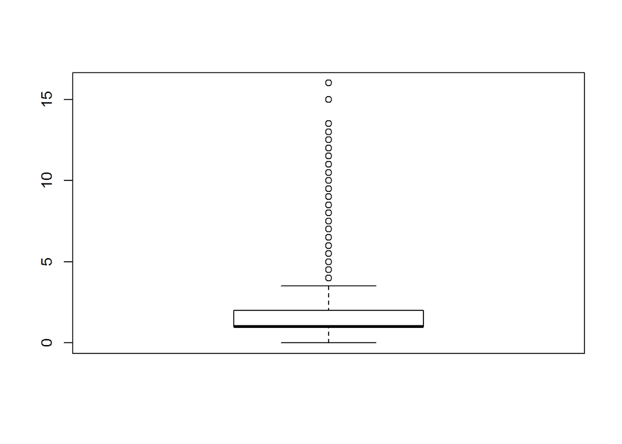

```r
boxplot(data$bathrooms)
```

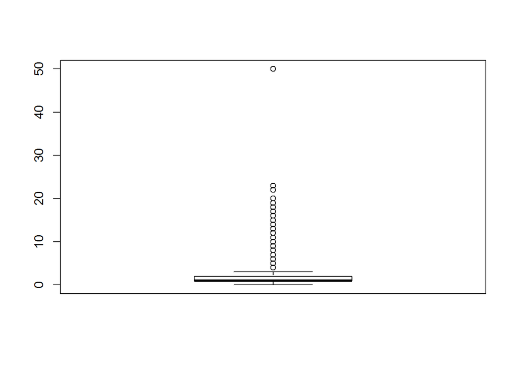

```r
boxplot(data$beds)
```

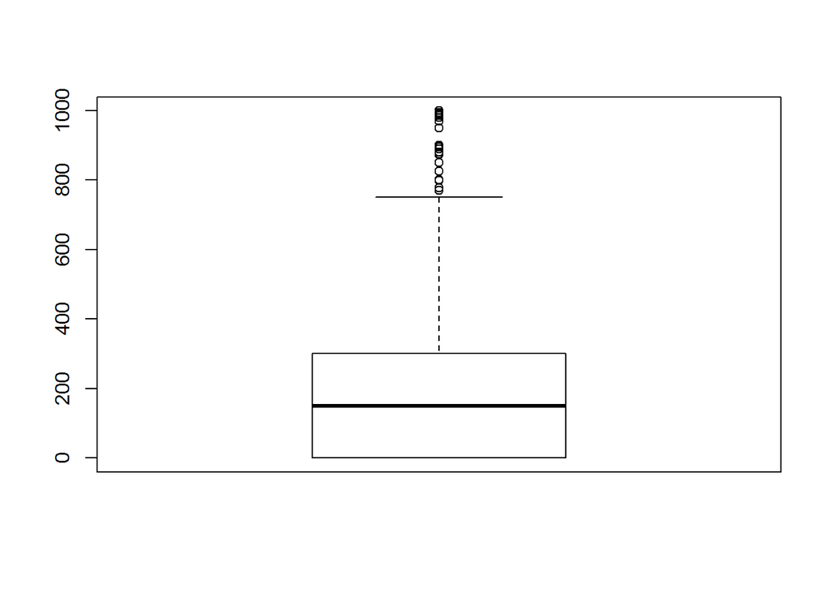

```r
boxplot(data$security_deposit)
```

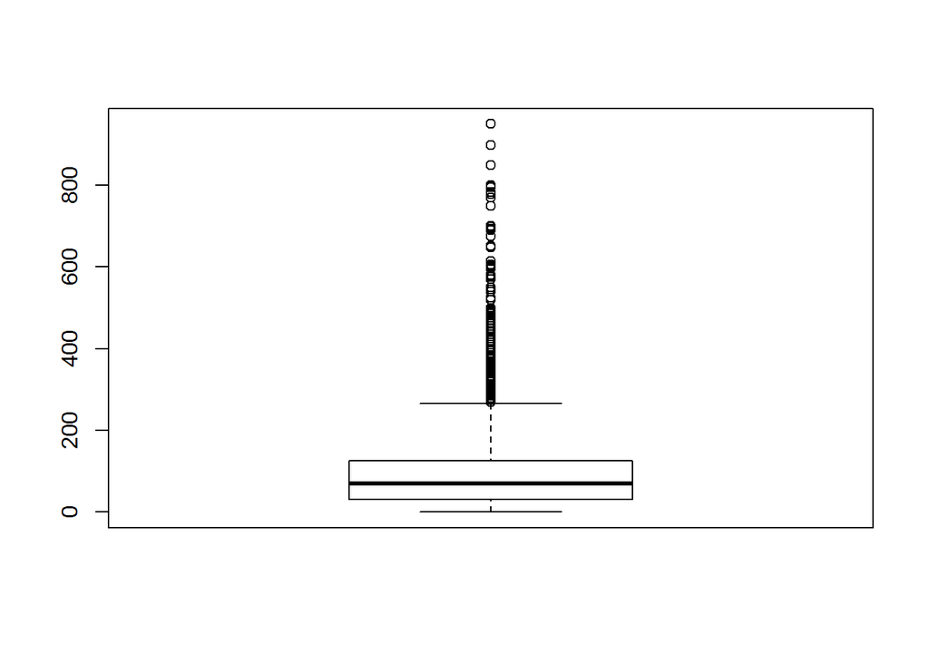

```r
boxplot(data$cleaning_fee)
```

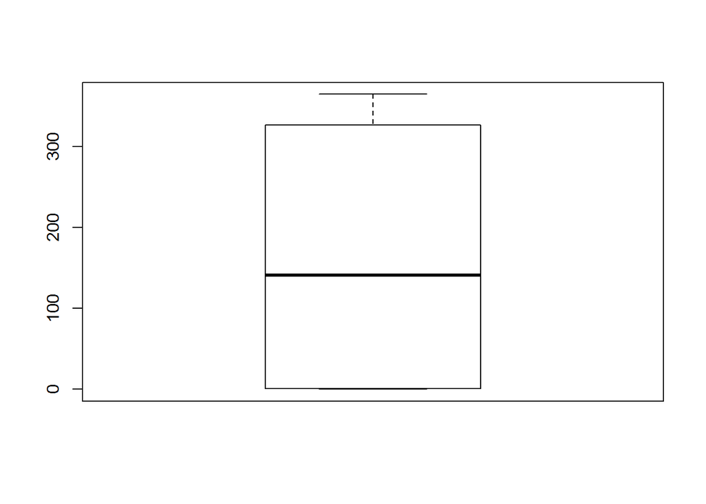

```r
boxplot(data$availability_365)
```

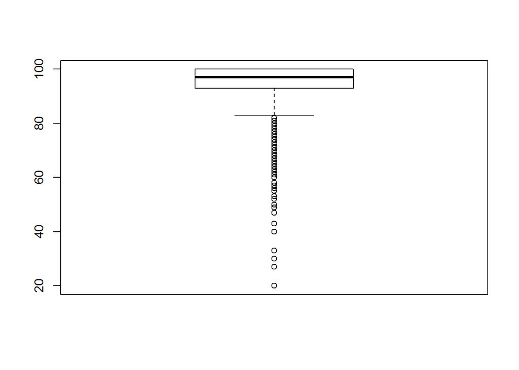

```r
boxplot(data$review_scores_rating)
boxplot(data$review_scores_rating)
```

[output not shown]

Dealing with the outliers in the dataset

```r
#Decided to replace the outlier values with the median values, if I used mean instead extreme outliers could possibly affect the mean

boxplot.stats(data$price)
```

```
## $stats
## [1]   0  69 105 175 334
##
## $n
## [1] 36702
##
## $conf
## [1] 104.1258 105.8742
##
## $out
##    [1] 395 450 900 399 600 395 350 550 340 369 418 550 515 699 595 500 695
##   [18] 361 375 450 750 450 350 525 575 350 335 550 350 550 585 375 399 400
##   [35] 350 450 400 425 500 400 590 899 610 450 489 500 695 349 499 450 750
##   [52] 350 700 350 500 375 395 565 459 340 490 430 374 850 510 449 900 359
##   [69] 699 825 425 350 400 700 409 350 382 649 399 799 499 632 450 790 399
```

[output cut: 167 more lines]

```r
data$price[which(data$price>334)]<-median(data$price,na.rm=TRUE) #334 is the uppper whisker, no values that are below the lower whisker

boxplot.stats(data$host_acceptance_rate)
```

```
## $stats
## [1]  63  85  97 100 100
##
## $n
## [1] 31814
##
## $conf
## [1] 96.86713 97.13287
##
## $out
##    [1]  0 33 35 62 13 13 24 24 50 60 35 56 47 33  0 35 44 60 55 60  0 17 50
##   [24] 60 50 29 59 55 60 46 44  0 46 20 50 62  0 50 44 60 59  0 59 31 57  0
##   [47] 16 16 60 60 25  0 50  0 59 60 53  0  0 44  0 57 29 60  0 29 14  0  0
##   [70] 25 59 60  0  0  0  8  0 13  0 50 25 50 13 33 46 59 29 46 46 60 43  0
##   [93] 18 42 42 56 47 33  0 50  0  0 32 40  0 59 25  0  0 58 58  0  0 56 57
```

[output cut: 163 more lines]

```r
data$host_acceptance_rate[which(data$host_acceptance_rate<63)]<-median(data$host_acceptance_rate,na.rm=TRUE)

boxplot.stats(data$bedrooms)
```

```
## $stats
## [1] 0 1 1 2 3
##
## $n
## [1] 37625
##
## $conf
## [1] 0.9918545 1.0081455
##
## $out
##    [1]  4  4  5  5  5  4  7  4  4  4  4  4  4  4  4  4  4  4  4  4  4  4  4
##   [24]  4  4  4  4  4  4  4  4  4  4  4  4  4  4  4  4  4  4  6  4  5  5  4
##   [47]  4  4  4  4  5  4  5  4  4  5  4  4  4  4  4  5  5  4  5  5  4  5  5
##   [70]  4  5  4  4  4  5  4  7  6  4  4  4  5  5  4  4  4  5  4  5  4  6  7
##   [93]  4  5  4  5  5  4  5  5  4  4  4  7  4  4  6  5  6  7  6  4  4  4  4
```

[output cut: 95 more lines]

```r
data$bedrooms[which(data$bedrooms>3)]<-median(data$bedrooms,na.rm=TRUE)#3 is the upper whisker, no values that are below the lower whisker

boxplot.stats(data$bathrooms)
```

```
## $stats
## [1] 0.0 1.0 1.0 2.0 3.5
##
## $n
## [1] 37691
##
## $conf
## [1] 0.9918616 1.0081384
##
## $out
##    [1] 11.0  4.0 11.0 11.0  8.0  8.0  8.0  8.0  8.0  8.0  8.0  8.0  8.0
##   [14]  8.0  8.0  4.5  4.0  8.0  8.0  8.0  7.5  4.5  4.5  5.0  4.0  4.0
##   [27]  5.5  8.0 11.0 11.0 11.0  5.0 11.0 11.0 11.0 11.0 11.0 11.0 11.0
##   [40] 11.0 11.0  4.5  4.0  4.0  4.0  4.5 11.0  5.0  4.5  4.5  4.5  4.0
##   [53]  4.0  4.0  8.0  8.0  8.0  8.0 11.5  4.5  4.5  4.0  4.5  6.5  4.5
```

[output cut: 99 more lines]

```r
data$bathrooms[which(data$bathrooms>3.5)]<-median(data$bathrooms,na.rm=TRUE)#3.5 is the upper whisker, no values that are below the lower whisker

boxplot.stats(data$beds)
```

```
## $stats
## [1] 0 1 1 2 3
##
## $n
## [1] 37340
##
## $conf
## [1] 0.9918235 1.0081765
##
## $out
##    [1]  5  4  5  5  5  5  4  5  5  9  5  5  6  4  4  4  4  4  7  4  4  4  4
##   [24]  4  6  4  8  4  4  4 11  5  6  6  8  4  7  4  5  4  4  5  4  4  4  4
##   [47] 15  4  4  6  6  5  4  5  6  5  4  8  4  9  5  5  8  6  4  5  5  4  4
##   [70]  5  9  5  4  5  5  4  4  4  6  6  6  6  4  4  4  5  4  4  6  4  4  4
##   [93]  5  6  7  7  5  4  5  9  4  5  7  4  4  4  6  4  4  4  4  4  8  4  5
```

[output cut: 217 more lines]

```r
data$beds[which(data$beds>3)]<-median(data$beds,na.rm=TRUE) #3 is the upper whisker, no values that are below the lower whisker

boxplot.stats(data$security_deposit)
```

```
## $stats
## [1]   0   0 150 300 750
##
## $n
## [1] 25265
##
## $conf
## [1] 147.0179 152.9821
##
## $out
##   [1] 950 800 850 799 800 800 900 800 995 800 800 800 800 800 800 900 800
##  [18] 900 800 825 800 800 800 800 800 800 800 800 800 800 900 800 800 800
##  [35] 800 989 900 800 777 800 800 999 800 800 800 800 890 800 800 800 900
##  [52] 850 900 900 950 800 900 800 800 800 800 800 800 800 800 800 800 800
##  [69] 800 850 800 900 950 800 900 800 800 800 800 800 800 800 800 800 950
##  [86] 800 800 800 900 800 800 800 850 800 800 850 800 800 800 800 800 800
## [103] 800 800 800 800 800 800 800 800 900 800 800 800 800 900 800 800 800
## [120] 850 800 850 995 800 800 950 800 900 899 800 850 900 950 850 800 800
## [137] 800 985 800 800 850 800 800 800 800 900 950 950 800 800 800 900 800
## [154] 800 800 800 999 999 950 800 850 800 850 970 800 800 999 800 980 900
## [171] 800 800 800 800 900 800 900 900 900 950 900 900 850 950 800 850 900
## [188] 800 800 800 800 800 900 800 800 800 800 800 900 800 850 800 800 800
## [205] 874 900 800 800 900 900 900 880 900 895 875 850 800 800 950 800 800
## [222] 800 800 800 850 950 800 850 800 800 990 990 800 800 900 800 770 800
## [239] 875 850 800 900 800 800 799 800 800 900 800 800 800 800
```

```r
data$security_deposit[which(data$security_deposit>750)]<-median(data$security_deposit,na.rm=TRUE) # 750 is the upper whisker, no values that are below the lower whisker

boxplot.stats(data$cleaning_fee)
```

```
## $stats
## [1]   0  30  70 125 265
##
## $n
## [1] 32715
##
## $conf
## [1] 69.17014 70.82986
##
## $out
##    [1] 400 275 300 300 300 400 300 450 500 500 300 300 450 500 300 500 300
##   [18] 420 275 350 275 275 450 300 299 333 360 540 540 420 420 275 350 400
##   [35] 300 480 333 320 500 420 327 650 300 651 333 275 350 300 399 368 475
##   [52] 300 350 300 950 500 651 360 550 500 471 300 485 300 300 300 350 300
##   [69] 300 300 500 300 600 300 300 500 295 400 350 350 500 325 285 500 300
```

[output cut: 109 more lines]

```r
data$cleaning_fee[which(data$cleaning_fee>265)]<-median(data$cleaning_fee,na.rm=TRUE) # 265 is the upper whisker, no values that are below the lower whisker

boxplot.stats(data$availability_365) #No outliers
```

```
## $stats
## [1]   0   1 141 327 365
##
## $n
## [1] 37728
##
## $conf
## [1] 138.3482 143.6518
##
## $out
## integer(0)
```

```r
boxplot.stats(data$review_scores_rating)
```

```
## $stats
## [1]  83  93  97 100 100
##
## $n
## [1] 29665
##
## $conf
## [1] 96.93579 97.06421
##
## $out
##    [1] 80 81 78 80 81 80 67 82 82 70 80 81 81 70 76 82 80 77 80 72 75 82 78
##   [24] 81 77 80 60 78 82 80 80 78 80 82 82 82 82 77 79 40 77 64 73 82 82 82
##   [47] 80 60 60 82 69 80 70 75 82 80 80 73 82 75 82 20 80 20 80 80 80 82 77
##   [70] 80 80 82 80 64 60 80 80 80 80 60 76 71 80 77 80 80 80 30 80 60 75 73
##   [93] 70 80 80 81 80 76 80 80 80 80 80 72 81 80 80 20 65 70 80 60 80 70 80
```

[output cut: 89 more lines]

```r
data$review_scores_rating[which(data$review_scores_rating<83)]<-median(data$review_scores_rating,na.rm=TRUE) # 83 is the lower whisker, no values above the upper whisker
```

Correlation of the numerical attributes in the dataset

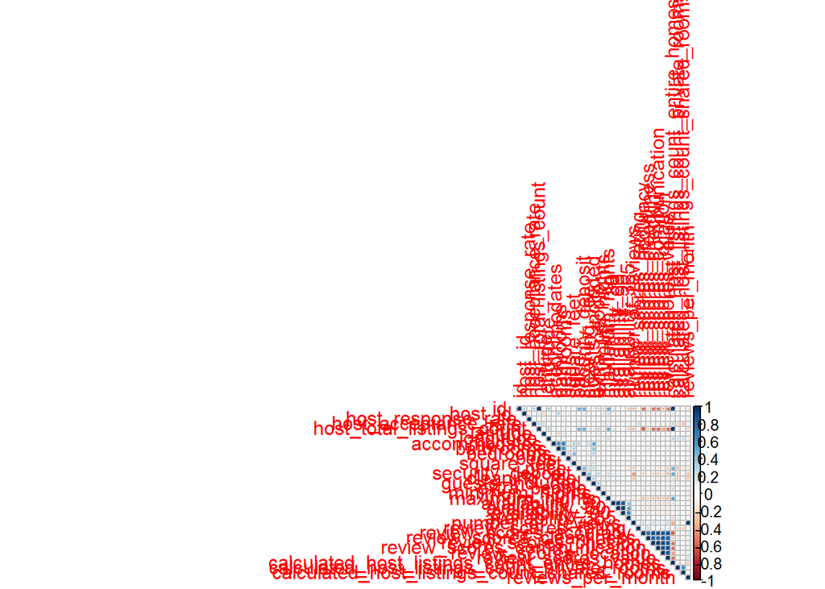

```r
#First create an numerical attribute dataframe of the dataset
#Then create a correlation matrix
#Remove any highly correlated attributes to one another

num_cols_only <- unlist(lapply(data,is.numeric)) #When you lapply is.numeric , it returns a list therefore you need to unlist to use it to make a numeric dataframe
data_numeric<-data[,num_cols_only]
cor_matrix<-cor(data_numeric,use="complete.obs")
library(corrplot)
corrplot(cor_matrix,type="upper")
```

```r
#Bedrooms and bathrooms is moderately postively correlated, we can remove bathrooms and keep bedrooms
#Availability 365 is moderately postively correlated with the other availability values which makes sense
#Accomadates number is moderately postively correlated with bedrooms,which makes sense as if you have more rooms you can accomodate more people
```

Dealing with NA values or missing values in the dataset

```r
#Now that the outliers have been replaced, I will want to replace any NA values with the mean value
#If there are records with missing values that are non numerical, I will remove that record if it is logical to do so

data$price[which(is.na(data$price)==TRUE)]<-mean(data$price,na.rm=TRUE)
data$bedrooms[which(is.na(data$bedrooms)==TRUE)]<-mean(data$bedrooms,na.rm=TRUE)
data$bathrooms[which(is.na(data$bathrooms)==TRUE)]<-mean(data$bathrooms,na.rm=TRUE)
data$beds[which(is.na(data$beds)==TRUE)]<-mean(data$beds,na.rm=TRUE)
data$security_deposit[which(is.na(data$security_deposit)==TRUE)]<-mean(data$security_deposit,na.rm=TRUE)
data$review_scores_rating[which(is.na(data$review_scores_rating)==TRUE)]<-mean(data$review_scores_rating,na.rm=TRUE)
data$review_scores_accuracy[which(is.na(data$review_scores_accuracy)==TRUE)]<-mean(data$review_scores_accuracy,na.rm=TRUE)
data$review_scores_checkin[which(is.na(data$review_scores_checkin)==TRUE)]<-mean(data$review_scores_checkin,na.rm=TRUE)
data$review_scores_cleanliness[which(is.na(data$review_scores_cleanliness)==TRUE)]<-mean(data$review_scores_cleanliness,na.rm=TRUE)
data$review_scores_value[which(is.na(data$review_scores_value)==TRUE)]<-mean(data$review_scores_value,na.rm=TRUE)
data$review_scores_location[which(is.na(data$review_scores_location)==TRUE)]<-mean(data$review_scores_location,na.rm=TRUE)
data$review_scores_communication[which(is.na(data$review_scores_communication)==TRUE)]<-mean(data$review_scores_communication,na.rm=TRUE)
data$cleaning_fee[which(is.na(data$cleaning_fee)==TRUE)]<-mean(data$cleaning_fee,na.rm=TRUE)

data<-data[which(!data$host_is_superhost==""),] # Only 3 values that were blank in the dataset, removed
data<-data[which(!data$bed_type==""),] #10 blank values removed
data<-data[which(!data$host_response_time==""),] # Only 3 values that were blank in the dataset, which also happens to be the same rows of the superhost that were blank
data<-data[which(!data$price==0),]#I also removed prices that were at 0, since it doesn't make sense for a listing to be at 0 for the context of the problem,since if it is 0 then that means it's free AirBnb.

#After removing the blank values in the dataset, there was still blank factors in the str(data)
str(data)
```

```
## 'data.frame':    37710 obs. of  71 variables:
##  $ id                                          : int  109 344 2708 2732 2864 3021 5728 5729 5843 6033 ...
##  $ last_scraped                                : Date, format: "2020-04-15" "2020-04-15" ...
##  $ name                                        : chr  "Amazing bright elegant condo park front *UPGRADED*" "Family perfect;Pool;Near Studios!" "Mirrored Mini-Suite with Fireplace - W. Hollywood" "Zen Life at the Beach" ...
##  $ summary                                     : chr  "*** Unit upgraded with new bamboo flooring, brand new Ultra HD 50\" Sony TV, new paint, new lighting, new mattr"| __truncated__ "This home is perfect for families; aspiring child actors w/parents; and friends vacationing for the summer or h"|…
##  $ space                                       : chr  "*** Unit upgraded with new bamboo flooring, brand new Ultra HD 50\" Sony TV, new paint, new lighting, new mattr"| __truncated__ "Cheerful & comfortable; near studios, amusement parks, downtown, beaches!  Central and modern; private, conveni"|…
##  $ description                                 : chr  "*** Unit upgraded with new bamboo flooring, brand new Ultra HD 50\" Sony TV, new paint, new lighting, new mattr"| __truncated__ "This home is perfect for families; aspiring child actors w/parents; and friends vacationing for the summer or h"|…
##  $ neighborhood_overview                       : chr  "" "Quiet-yet-close to all the fun in LA! Hollywood, Universal Studios, beaches, great hikes and more are all minutes away." "We are minutes away from the Mentor Language Institute, Kings College, Musicians Institute, and many film schoo"| __t…
##  $ notes                                       : chr  "" "One dog may be on premises, friendly and cared for by caretaker.  A great addition to stabilize kids-away-from-"| __truncated__ "BlendtecÂ® Designer 625 Blender Bundle with Twister Jar MORE THAN JUST SMOOTHIES: From hot soup to ice cream a…
##  $ transit                                     : chr  "" "Short drive to subway and elevated trains running to major tourist spots in LA; freeways minutes away as well. "| __truncated__ "There are many buses; bus stops going in every direction are just around the corner. The subway is five minute…
##  $ access                                      : chr  "" "Pool, patio and self-contained main house all accessible freely by guests.  Garage, pool house and back caretak"| __truncated__ "Kitchen with new refrigerator, dishwasher, stove and oven with new plank floors. Jacuzzi and sundeck New gym w…
##  $ interaction                                 : chr  "" "Host and caretaker may be available throughout your stay to assist in troubleshooting with local information/am"| __truncated__ "I am friendly and available to help you with your needs even before you arrive. I am seldom seen as I am in an…
##  $ house_rules                                 : chr  "Camelot NEW RESIDENTSâ\200\231 GENERAL INFORMATION   File:  New Residents Info  1 Created on 12/13/05  Hello, a"| __truncated__ "Host asks that guests refrain from partying loudly into the evening on back patio/pool area.  Guest swim at the"|…
##  $ host_id                                     : int  521 767 3008 3041 3207 3415 9171 9171 9171 11619 ...
##  $ host_since                                  : Date, format: "2008-06-27" "2008-07-11" ...
```

[output cut: 57 more lines]

```r
#Removed for analysis
levels(data$host_is_superhost)[which(levels(data$host_is_superhost)=="")]<-NA
levels(data$bed_type)[which(levels(data$bed_type)=="")]<-NA
levels(data$host_response_time)[which(levels(data$host_response_time)=="")]<-NA
levels(data$host_identity_verified)[which(levels(data$host_identity_verified)=="")]<-NA
```

Backward elimination and checking assumptions of the linear regression model

```r
#Still trying to figure out the best way incorporate amenities into my models,and still a work in progress for the final results/report
model<-lm(price~bedrooms+property_type+beds+host_is_superhost+neighbourhood_cleansed+cleaning_fee+security_deposit+
            review_scores_rating+bed_type+review_scores_accuracy+review_scores_checkin+review_scores_cleanliness+
            review_scores_communication+review_scores_location+review_scores_value,data=data)

library(MASS)
summary(model)
```

```
##
## Call:
## lm(formula = price ~ bedrooms + property_type + beds + host_is_superhost +
##     neighbourhood_cleansed + cleaning_fee + security_deposit +
##     review_scores_rating + bed_type + review_scores_accuracy +
##     review_scores_checkin + review_scores_cleanliness + review_scores_communication +
##     review_scores_location + review_scores_value, data = data)
##
## Residuals:
##      Min       1Q   Median       3Q      Max
## -189.972  -32.463   -8.119   22.527  254.250
##
## Coefficients:
##                                                               Estimate
## (Intercept)                                                  1.238e+01
## bedrooms                                                     2.247e+01
## property_typeApartment                                      -1.632e+01
## property_typeBarn                                           -2.555e+01
## property_typeBed and breakfast                              -2.668e+01
## property_typeBoat                                           -2.088e+01
## property_typeBoutique hotel                                  2.198e+01
## property_typeBungalow                                       -1.478e+01
## property_typeBus                                             7.729e+01
## property_typeCabin                                           2.786e+00
## property_typeCamper/RV                                      -1.045e+01
## property_typeCampsite                                       -3.328e+01
## property_typeCasa particular (Cuba)                         -3.070e+01
## property_typeCastle                                         -4.489e+00
## property_typeCave                                           -2.574e+01
## property_typeChalet                                         -7.520e+01
## property_typeCondominium                                    -1.404e+01
## property_typeCottage                                        -5.189e+00
## property_typeDome house                                     -4.307e+01
## property_typeDorm                                           -8.815e+01
## property_typeEarth house                                    -9.842e+00
## property_typeFarm stay                                      -1.453e+01
## property_typeGuest suite                                    -1.422e+01
## property_typeGuesthouse                                     -3.026e+00
## property_typeHostel                                         -4.755e+01
## property_typeHotel                                           2.161e+01
```

[output cut: 1268 more lines]

```
## bed_typeFuton                                               0.327581
## bed_typePull-out Sofa                                       0.168867
## bed_typeReal Bed                                            0.000110 ***
## review_scores_accuracy                                      0.722308
## review_scores_checkin                                       0.028232 *
## review_scores_cleanliness                                   1.61e-14 ***
## review_scores_communication                                 0.766834
## review_scores_location                                      3.42e-12 ***
## review_scores_value                                         8.80e-10 ***
## ---
## Signif. codes:  0 '***' 0.001 '**' 0.01 '*' 0.05 '.' 0.1 ' ' 1
##
## Residual standard error: 51.83 on 37385 degrees of freedom
## Multiple R-squared:  0.3614, Adjusted R-squared:  0.3559
## F-statistic: 65.31 on 324 and 37385 DF,  p-value: < 2.2e-16
```

```r
stepAIC(model,direction="backward") #Through backward elimination, we eliminated the attribute review_score_accuracy and review_score_communication
```

```
## Start:  AIC=298075.7
## price ~ bedrooms + property_type + beds + host_is_superhost +
##     neighbourhood_cleansed + cleaning_fee + security_deposit +
##     review_scores_rating + bed_type + review_scores_accuracy +
##     review_scores_checkin + review_scores_cleanliness + review_scores_communication +
##     review_scores_location + review_scores_value
##
##                                Df Sum of Sq       RSS    AIC
## - review_scores_communication   1       236 100419423 298074
## - review_scores_accuracy        1       339 100419526 298074
## <none>                                      100419187 298076
## - review_scores_rating          1     11689 100430876 298078
## - review_scores_checkin         1     12931 100432118 298079
## - host_is_superhost             1     16111 100435298 298080
## - review_scores_value           1    100979 100520166 298112
## - bed_type                      4    127334 100546521 298115
## - review_scores_location        1    130176 100549363 298123
## - review_scores_cleanliness     1    158499 100577686 298133
## - security_deposit              1    447000 100866187 298241
## - beds                          1    680076 101099263 298328
## - property_type                45   2216048 102635235 298809
## - neighbourhood_cleansed      263   7599659 108018846 300301
## - bedrooms                      1   6883321 107302508 300574
## - cleaning_fee                  1   8355958 108775145 301088
##
## Step:  AIC=298073.8
## price ~ bedrooms + property_type + beds + host_is_superhost +
##     neighbourhood_cleansed + cleaning_fee + security_deposit +
##     review_scores_rating + bed_type + review_scores_accuracy +
##     review_scores_checkin + review_scores_cleanliness + review_scores_location +
##     review_scores_value
##
##                              Df Sum of Sq       RSS    AIC
## - review_scores_accuracy      1       242 100419665 298072
## <none>                                    100419423 298074
## - review_scores_rating        1     11607 100431030 298076
## - review_scores_checkin       1     14590 100434013 298077
## - host_is_superhost           1     16128 100435551 298078
## - review_scores_value         1    101536 100520959 298110
## - bed_type                    4    127222 100546645 298114
```

[output cut: 15 more lines]

```
##                              Df Sum of Sq       RSS    AIC
## <none>                                    100419665 298072
## - review_scores_rating        1     11527 100431192 298074
## - host_is_superhost           1     16027 100435692 298076
## - review_scores_checkin       1     16966 100436630 298076
## - bed_type                    4    127160 100546825 298112
## - review_scores_value         1    124302 100543967 298117
## - review_scores_location      1    133447 100553112 298120
## - review_scores_cleanliness   1    171146 100590811 298134
## - security_deposit            1    447074 100866739 298237
## - beds                        1    679934 101099598 298324
## - property_type              45   2215804 102635469 298805
## - neighbourhood_cleansed    263   7599394 108019058 300297
## - bedrooms                    1   6885315 107304980 300571
## - cleaning_fee                1   8355580 108775244 301084
```

```
##
## Call:
## lm(formula = price ~ bedrooms + property_type + beds + host_is_superhost +
##     neighbourhood_cleansed + cleaning_fee + security_deposit +
##     review_scores_rating + bed_type + review_scores_checkin +
##     review_scores_cleanliness + review_scores_location + review_scores_value,
##     data = data)
##
## Coefficients:
##                                                 (Intercept)
##                                                    12.66367
##                                                    bedrooms
##                                                    22.47472
##                                      property_typeApartment
##                                                   -16.33764
##                                           property_typeBarn
##                                                   -25.56432
##                              property_typeBed and breakfast
##                                                   -26.66146
##                                           property_typeBoat
##                                                   -20.84395
##                                 property_typeBoutique hotel
##                                                    21.97274
##                                       property_typeBungalow
##                                                   -14.79717
##                                            property_typeBus
##                                                    77.22083
##                                          property_typeCabin
##                                                     2.78239
##                                      property_typeCamper/RV
##                                                   -10.46939
##                                       property_typeCampsite
##                                                   -33.27789
##                         property_typeCasa particular (Cuba)
##                                                   -30.72970
##                                         property_typeCastle
##                                                    -4.49097
##                                           property_typeCave
##                                                   -25.75819
##                                         property_typeChalet
```

[output cut: 600 more lines]

```
##                                                    -2.47330
##                                               bed_typeFuton
##                                                     7.44929
##                                       bed_typePull-out Sofa
##                                                    11.61426
##                                            bed_typeReal Bed
##                                                    24.03258
##                                       review_scores_checkin
##                                                    -1.31612
##                                   review_scores_cleanliness
##                                                     3.44794
##                                      review_scores_location
##                                                     3.94972
##                                         review_scores_value
##                                                    -3.46092
```

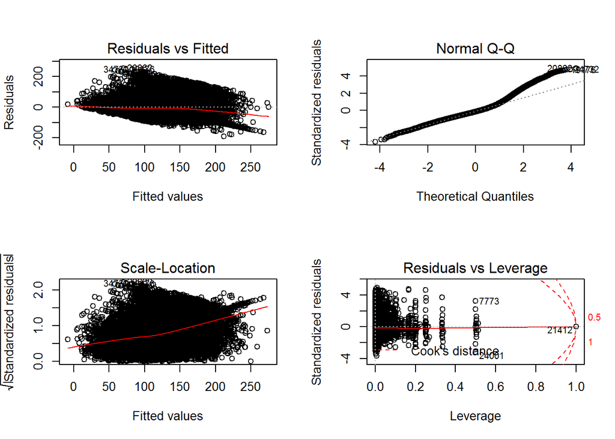

```r
model<-lm(price~bedrooms+property_type+beds+host_is_superhost+neighbourhood_cleansed+cleaning_fee+security_deposit+
            review_scores_rating+bed_type+review_scores_checkin+review_scores_cleanliness
          +review_scores_location+review_scores_value,data=data) # removed due to backward regression

par(mfrow=c(2,2))#Easier to look at the plots in a 2x2 window
plot(model)
```

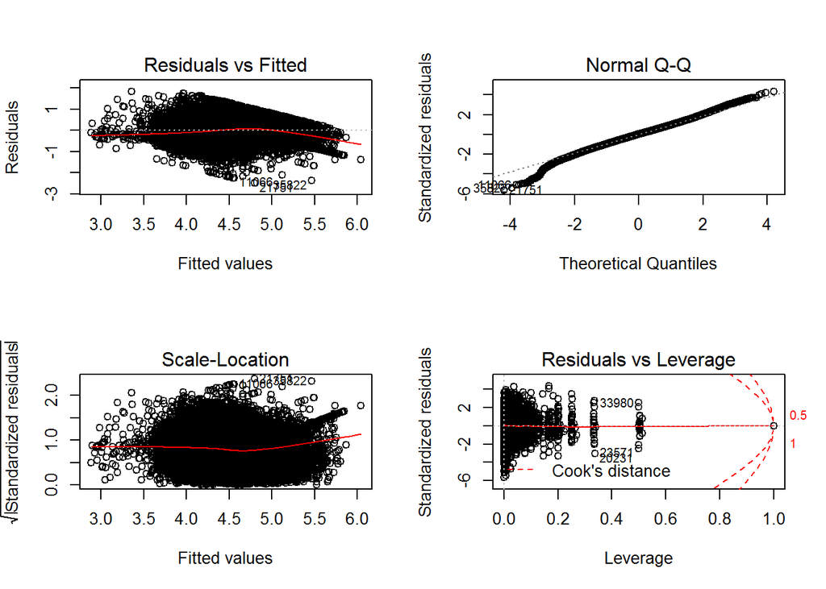

```r
#Based on the plots, it looks like there isn't constant variance, but the other assumptions are upheld
#To address this I transformed the dependent variable by taking the natural log of the price


model<-lm(log(price)~bedrooms+property_type+beds+host_is_superhost+neighbourhood_cleansed+cleaning_fee+security_deposit+
            review_scores_rating+bed_type+review_scores_checkin+review_scores_cleanliness
          +review_scores_location+review_scores_value,data=data)


plot(model)
```

In addition, I created a variation to the above model, since the context of the problem is to help new listers determine their price per night, it wouldn’t make sense for them to have a rating or superhost on AirBnb.

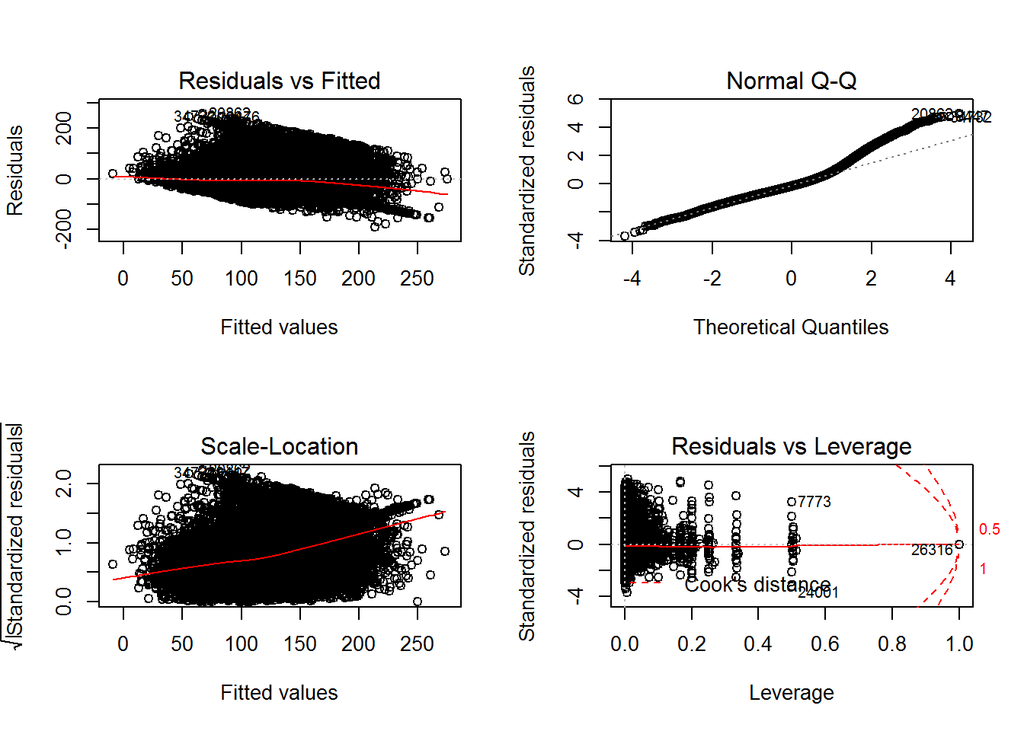

```r
model2<-lm(price~bedrooms+property_type+beds+neighbourhood_cleansed+cleaning_fee+security_deposit+bed_type,data=data)
par(mfrow=c(2,2))#Easier to look at the plots in a 2x2 window
plot(model2)
```

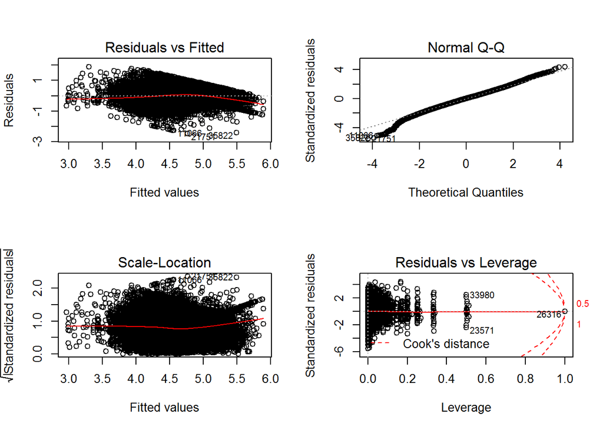

```r
#Again, need to log the price as there isn't constant variance and for a better model

model2<-lm(log(price)~bedrooms+property_type+beds+neighbourhood_cleansed+cleaning_fee+security_deposit+bed_type,data=data)
plot(model2)
```

Spliting the dataset into a training set and test set using 10 cross fold validation. Then create the above model using the 10 fold cross validation. The benefit of 10 cross fold validation, is that it can use the entire dataset to train the model on.

It seems that the dataset provided by insideairbnb website doesn’t show when they host actually put up their listing, but provides when they scraped the listing off of the website. I also checked actual AirBnb website as well,there’s no way to find out the actual time they put up the listing.However, I do find it important to know when they scraped off the listing, since it means that, that was the price per night of their listing on the date of the scraping, which means that the host still thought that their property was worth that much at the time of the scrap and market conditions are still represented at the time of the scraping.

```r
#Looking at the dataset of when the data is scraped,it is all in 2020 with a few days difference for some of the listings
library(caret)
train_cv<-trainControl(method="cv",number=10) #10 cross fold validation

model_cv<-train(log(price)~bedrooms+property_type+beds+host_is_superhost+neighbourhood_cleansed+cleaning_fee+security_deposit+
            review_scores_rating+bed_type+review_scores_checkin+review_scores_cleanliness
          +review_scores_location+review_scores_value,data=data,trControl=train_cv,method="lm")
print(model_cv)
```

```
## Linear Regression
##
## 37710 samples
##    13 predictor
##
## No pre-processing
## Resampling: Cross-Validated (10 fold)
## Summary of sample sizes: 33938, 33938, 33940, 33938, 33940, 33940, ...
## Resampling results:
##
##   RMSE      Rsquared   MAE
##   0.444634  0.4091557  0.3465463
##
## Tuning parameter 'intercept' was held constant at a value of TRUE
```

```r
#By printing our model, we have three metrics we can look at for our model, RMSE,R2,and MAE.We can look at these measures


#I looked into the warning message, which may be the result of colinearity of the independent variables, however I already looked into  numberic variables in the model and I didn't find anything of the sort.Thus, I think it MAY be an false warning.



#The model variation we did above, I will do again for the 10 cross fold validation

model2_cv<-train(log(price)~bedrooms+property_type+beds+neighbourhood_cleansed+cleaning_fee+security_deposit+bed_type,data=data,trControl=train_cv,method="lm")
print(model2_cv)
```

```
## Linear Regression
##
## 37710 samples
##     7 predictor
##
## No pre-processing
## Resampling: Cross-Validated (10 fold)
## Summary of sample sizes: 33940, 33941, 33938, 33940, 33938, 33938, ...
## Resampling results:
##
##   RMSE       Rsquared   MAE
##   0.4466809  0.4036917  0.3480322
##
## Tuning parameter 'intercept' was held constant at a value of TRUE
```

Multinomial Logistic Model using 10 Fold Cross Validation

```r
#First split the price into categories such as low , medium , high.I think this is important to look at since when it comes to the tourism or hospitality industry, as a consumer myself I look at the price as a way to determine the luxary of an accomadation.Higher the price the more luxurious it is. I'm thinking of renaming these categories to other categories that will fit the context of the problem better, these could be temporary names.


range(data$price)
```

```
## [1]  10 334
```

```r
#10 is the loweest , 334 is the highest price , I want to split it between low, medium and high
#Thus, lowest I will set it as 10-118 as low inclusively, 119- 226 inclusively as medium, and 227-334 inclusively as high.

data$price_level<-NA

data$price_level[which(data$price<=118)]<-"Low"
data$price_level[which(data$price>=119)]<-"Medium"
data$price_level[which(data$price>=227)]<-"High"


data$price_level<-as.factor(data$price_level)
```

```r
train_cv<-trainControl(method="cv",number=10)

model_log_cv<-train(price_level~bedrooms+property_type+beds+host_is_superhost+neighbourhood_cleansed+cleaning_fee+security_deposit+
            review_scores_rating+bed_type+review_scores_checkin+review_scores_cleanliness
          +review_scores_location+review_scores_value,data=data,trControl=train_cv,method="multinom")
print(model_log_cv)
```

```
## Penalized Multinomial Regression
##
## 37710 samples
##    13 predictor
##     3 classes: 'High', 'Low', 'Medium'
##
## No pre-processing
## Resampling: Cross-Validated (10 fold)
## Summary of sample sizes: 33939, 33939, 33939, 33939, 33938, 33939, ...
## Resampling results across tuning parameters:
##
##   decay  Accuracy   Kappa
##   0e+00  0.6776449  0.2731481
##   1e-04  0.6776449  0.2731481
##   1e-01  0.6776183  0.2717542
##
## Accuracy was used to select the optimal model using the largest value.
## The final value used for the model was decay = 1e-04.
```

```r
#Using a 10 fold cross validation and multinomial logistic regression takes a long time to train the model.

#Again we have some metrics to look at for our multinomial regression model.
```

I made a confusion matrix here to see more metrics of the multinomial logistic regression.

```r
log_predictions <-predict(model_log_cv,data)
actual_values <-data$price_level


confusionMatrix(log_predictions,actual_values)
```

```
## Confusion Matrix and Statistics
##
##           Reference
## Prediction  High   Low Medium
##     High     241   358    141
##     Low     1239 21551   6614
##     Medium  1427  2165   3974
##
## Overall Statistics
##
##                Accuracy : 0.6833
##                  95% CI : (0.6785, 0.688)
##     No Information Rate : 0.6384
##     P-Value [Acc > NIR] : < 2.2e-16
##
##                   Kappa : 0.286
##
##  Mcnemar's Test P-Value : < 2.2e-16
##
## Statistics by Class:
##
##                      Class: High Class: Low Class: Medium
## Sensitivity             0.082903     0.8952        0.3704
## Specificity             0.985662     0.4241        0.8669
## Pos Pred Value          0.325676     0.7329        0.5252
## Neg Pred Value          0.927887     0.6962        0.7759
## Prevalence              0.077088     0.6384        0.2845
## Detection Rate          0.006391     0.5715        0.1054
## Detection Prevalence    0.019623     0.7797        0.2006
## Balanced Accuracy       0.534283     0.6596        0.6186
```

Multinomial Logistic Regression Model Variation

```r
model2_log_cv<-train(price_level~bedrooms+property_type+beds+neighbourhood_cleansed+cleaning_fee+security_deposit+bed_type,data=data,trControl=train_cv,method="multinom")
print(model2_log_cv)
```

```
## Penalized Multinomial Regression
##
## 37710 samples
##     7 predictor
##     3 classes: 'High', 'Low', 'Medium'
##
## No pre-processing
## Resampling: Cross-Validated (10 fold)
## Summary of sample sizes: 33939, 33939, 33940, 33941, 33938, 33938, ...
## Resampling results across tuning parameters:
##
##   decay  Accuracy   Kappa
##   0e+00  0.6766639  0.2692961
##   1e-04  0.6766374  0.2692297
##   1e-01  0.6768760  0.2689322
##
## Accuracy was used to select the optimal model using the largest value.
## The final value used for the model was decay = 0.1.
```

```r
log2_prediction<-predict(model2_log_cv,data)
confusionMatrix(log2_prediction,actual_values)
```

```
## Confusion Matrix and Statistics
##
##           Reference
## Prediction  High   Low Medium
##     High     219   337    124
##     Low     1257 21600   6707
##     Medium  1431  2137   3898
##
## Overall Statistics
##
##                Accuracy : 0.682
##                  95% CI : (0.6772, 0.6867)
##     No Information Rate : 0.6384
##     P-Value [Acc > NIR] : < 2.2e-16
##
##                   Kappa : 0.2801
##
##  Mcnemar's Test P-Value : < 2.2e-16
##
## Statistics by Class:
##
##                      Class: High Class: Low Class: Medium
## Sensitivity             0.075335     0.8972        0.3633
## Specificity             0.986754     0.4160        0.8678
## Pos Pred Value          0.322059     0.7306        0.5221
## Neg Pred Value          0.927410     0.6963        0.7741
## Prevalence              0.077088     0.6384        0.2845
## Detection Rate          0.005807     0.5728        0.1034
## Detection Prevalence    0.018032     0.7840        0.1980
## Balanced Accuracy       0.531045     0.6566        0.6155
```